# Eelgrass_community_structure_analyses

Wendel Raymond

January 16, 2018

# Analyses for testing hypotheses related to eelgrass community structure

**Question** What is the structure of eelgrass communities across a gradient of sea otter impacts?

**Overall Hypothesis** If top-down (sea otter) forces are structuring eelgrass communities, then we would expect alternating relative abundance from trophic level to trophic level.

## Outline

1. Description of data
2. Testing assumptions
   - normality
   - co-linearity
3. Models

## 1. Data

**Response metrics** 1. eelgrass aboveground biomass density (g / m<sup>2</sup>) 2. eelgrass belowground biomass density (g / m<sup>2</sup>) 3. eelgrass shoot density (count / m<sup>2</sup>) 4. ratio of aboveground to belowground biomass density (g / m<sup>2</sup>) 5. epiphyte load (g epiphyte / g eelgrass) 6. total grazer load (g grazers/ g eelgrass) + gastropod load (g grazers/ g eelgrass) + crustaecean load (g grazers/ g eelgrass) 7. crab biomass (g) 8. fish standarized by … candidates are length, gape size, biomass

**Primary explanatory factors** Not all these fators will necessarily be used in all models 1. Time 2. Sediment type (primary sediment type from the “inside” eelgrass transect) 3. Percent light

**Secondary explanatory factors** Factors that are more specific to certain tests 1. crab biomass (g) 2. fish

## 2. Testing assumptions

### Normality

```r
#tran.dat <- tran.dat %>%
  #filter(site != "2017_L_01" & site != "2017_H_01") %>%
  #filter(quadrat < 9)

#crab <- crab.dat %>%
  #filter(site != "2017_L_01" & site != "2017_H_01") %>%
  #group_by(site, string) %>%
  #summarise(mass_g = sum(mass_g))

#crab.dat <- merge(unique(crab.dat[, 1:8]), crab, by = "site", all.y = TRUE)
```

Eelgrass shoot density appears reasonably normal but fails SW test. Further test indicate that sqrt transformation achives normality.

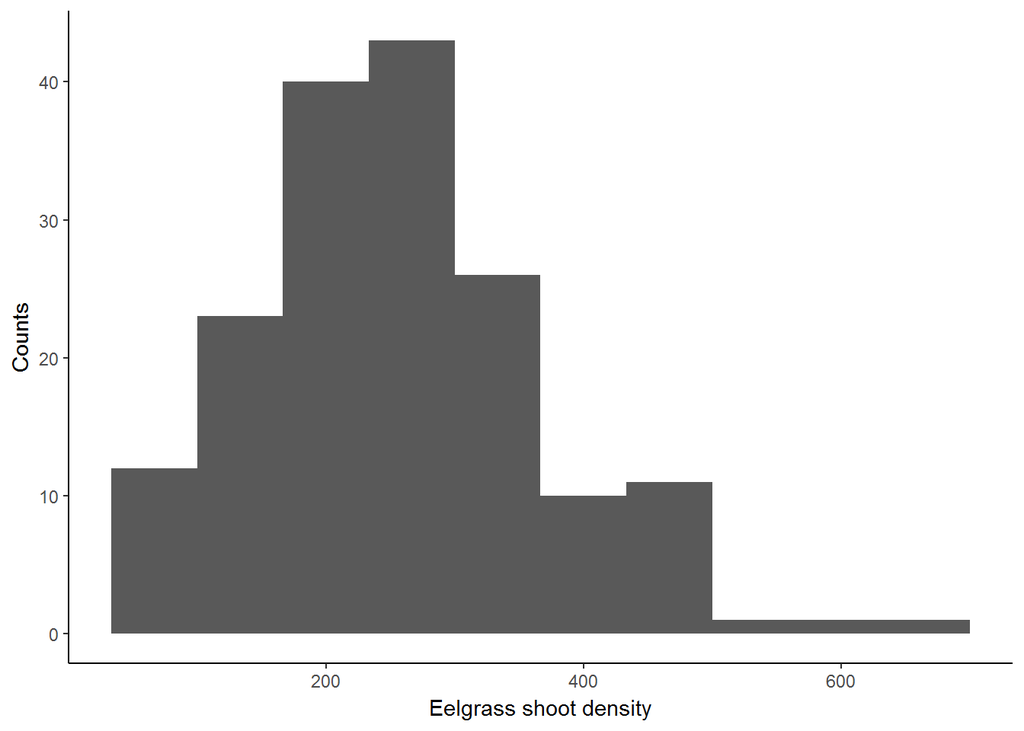

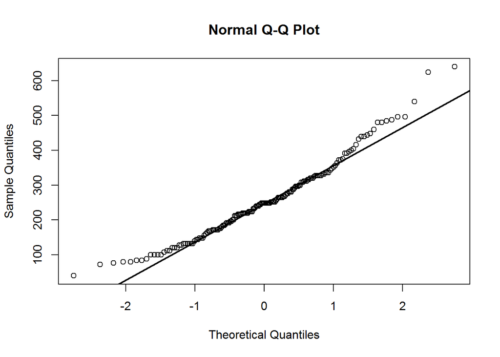

```
##
##  Shapiro-Wilk normality test
##
## data:  tran.dat$eelgrass_shoots_msq
## W = 0.96525, p-value = 0.0003267
```

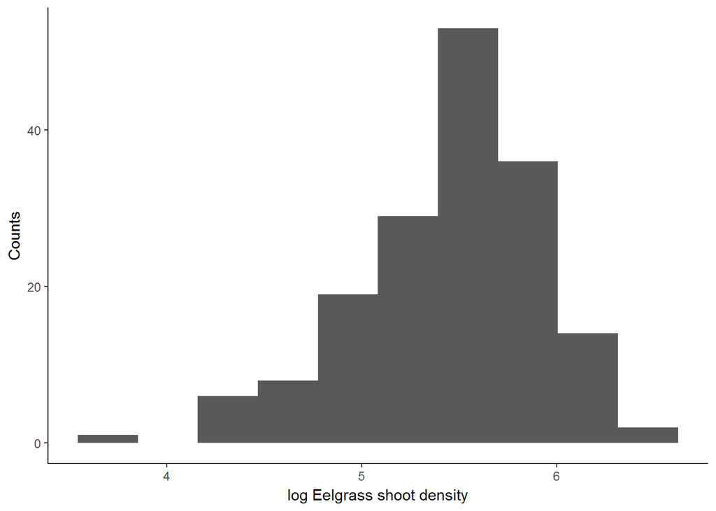

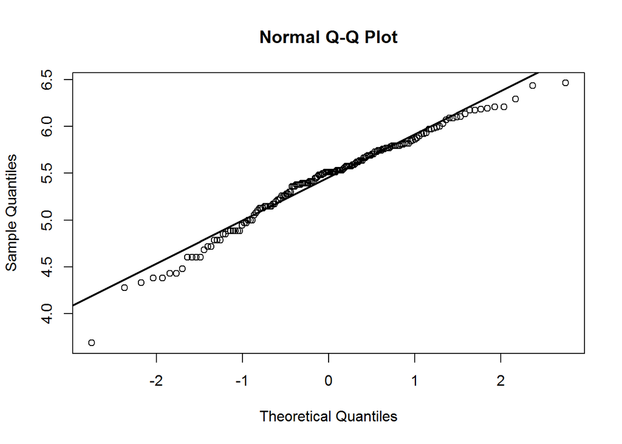

```
##
##  Shapiro-Wilk normality test
##
## data:  log(tran.dat$eelgrass_shoots_msq)
## W = 0.97461, p-value = 0.003547
```

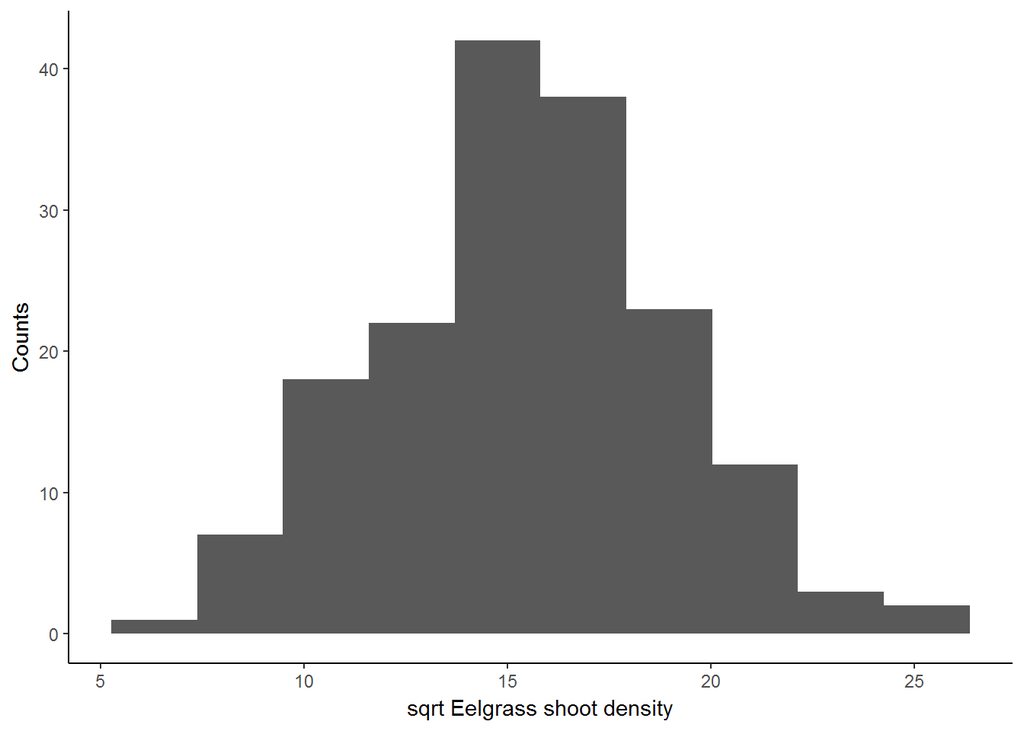

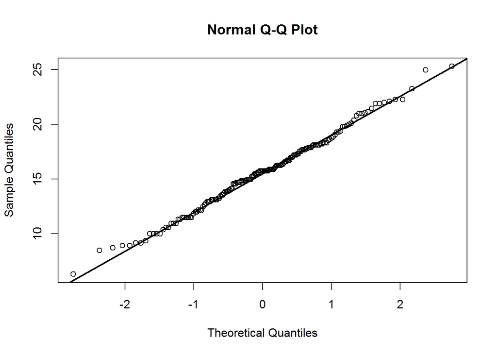

```
##
##  Shapiro-Wilk normality test
##
## data:  sqrt(tran.dat$eelgrass_shoots_msq)
## W = 0.99422, p-value = 0.7528
```

Aboveground biomass shows some right skewness suggesting ln transformation. Log transformation was not super great. However square roor transformation appears more helpful. SW tests all indicate at least some non-normality, but sqrt transformation is the best.

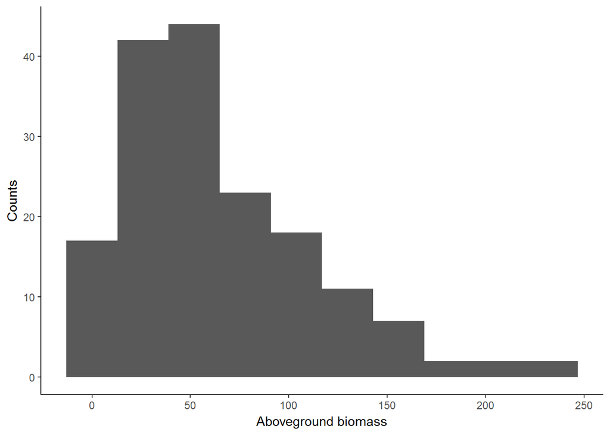

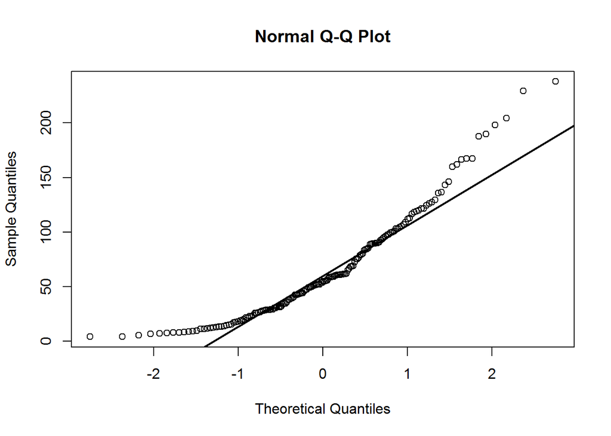

```
##
##  Shapiro-Wilk normality test
##
## data:  tran.dat$ag_mass
## W = 0.90653, p-value = 7.369e-09
```

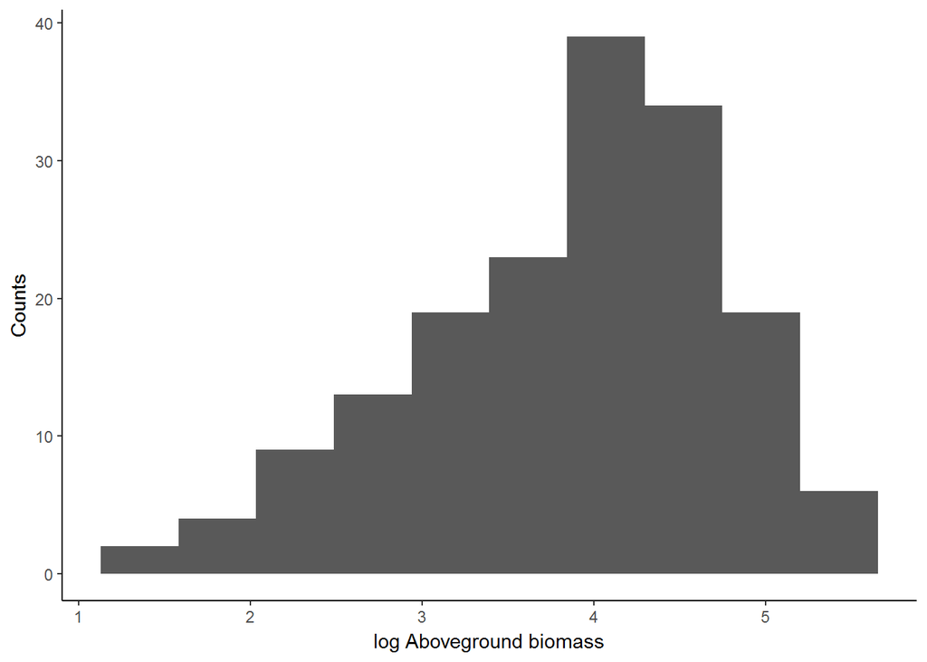

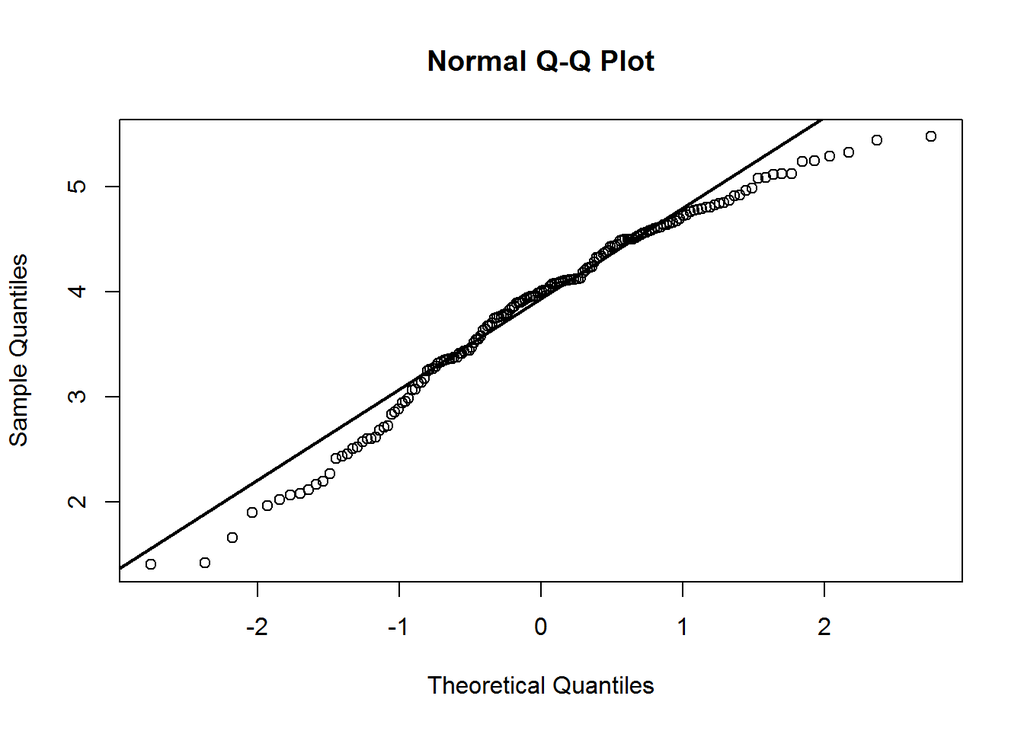

```
##
##  Shapiro-Wilk normality test
##
## data:  log(tran.dat$ag_mass)
## W = 0.9651, p-value = 0.0003151
```

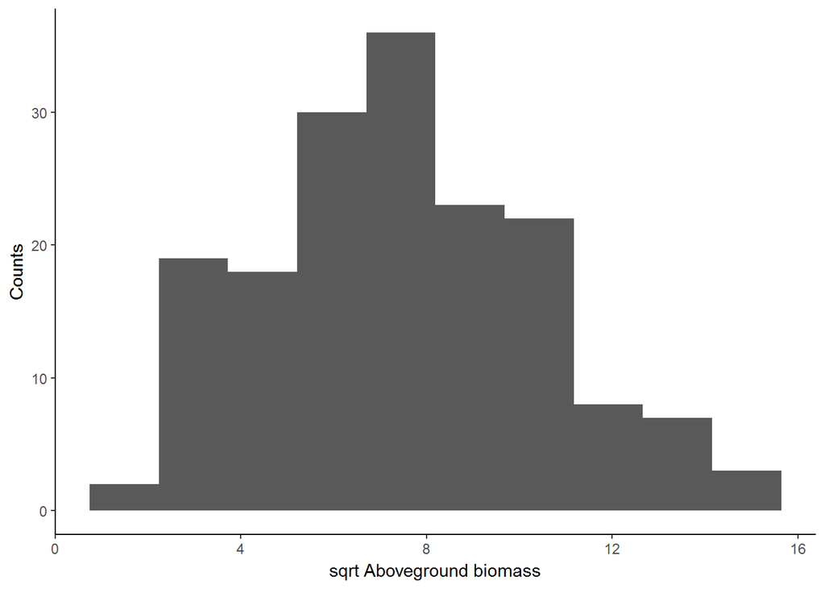

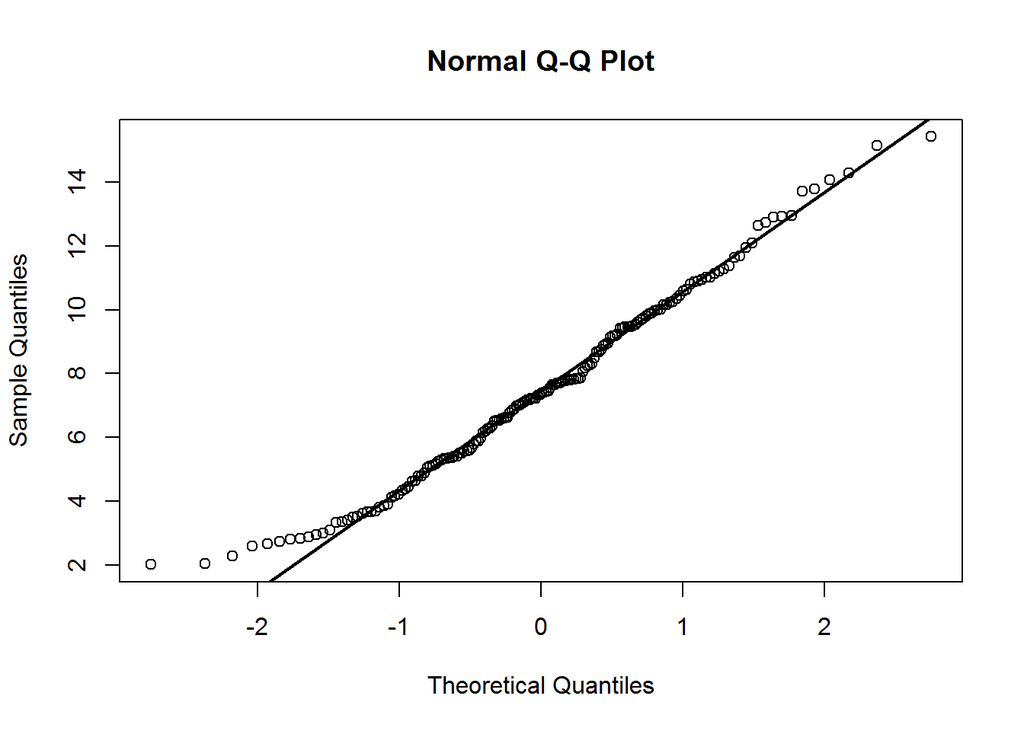

```
##
##  Shapiro-Wilk normality test
##
## data:  sqrt(tran.dat$ag_mass)
## W = 0.98293, p-value = 0.03696
```

Belowground biomass also shows right skewness. Both log and square root tranformations improve normality. SW test indicates that log transformation achieves normality.

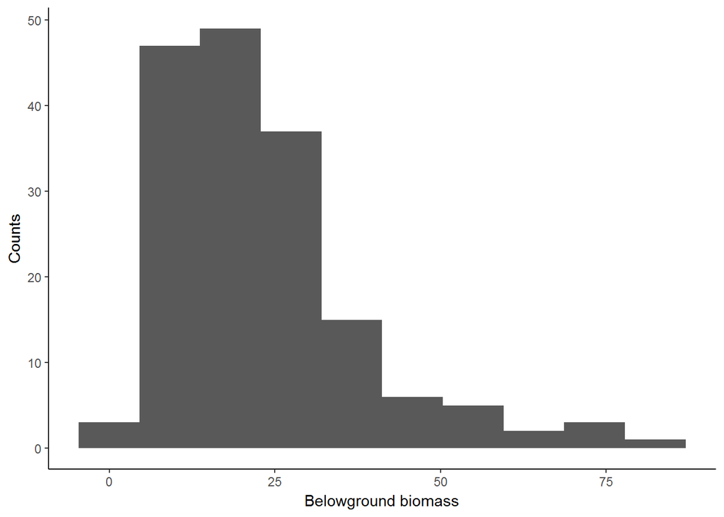

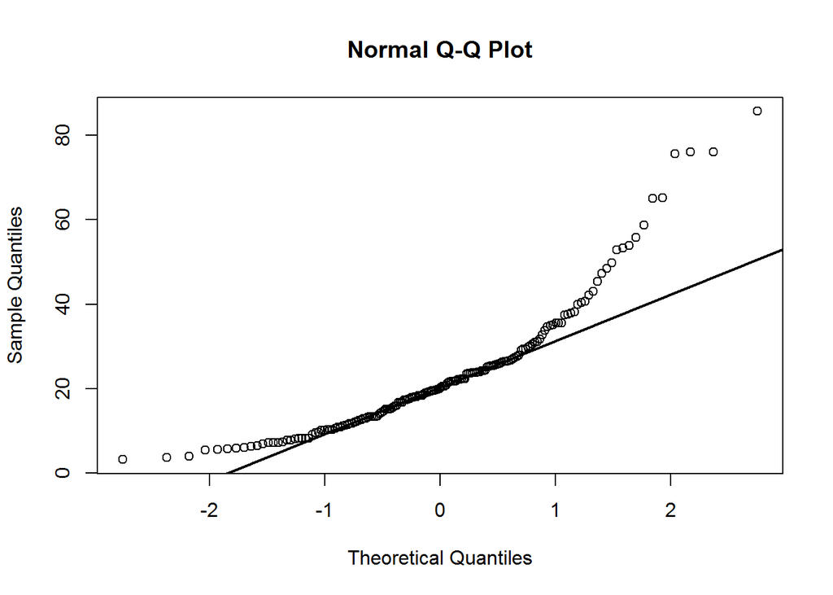

```
##
##  Shapiro-Wilk normality test
##
## data:  tran.dat$bg_mass
## W = 0.86442, p-value = 3.691e-11
```

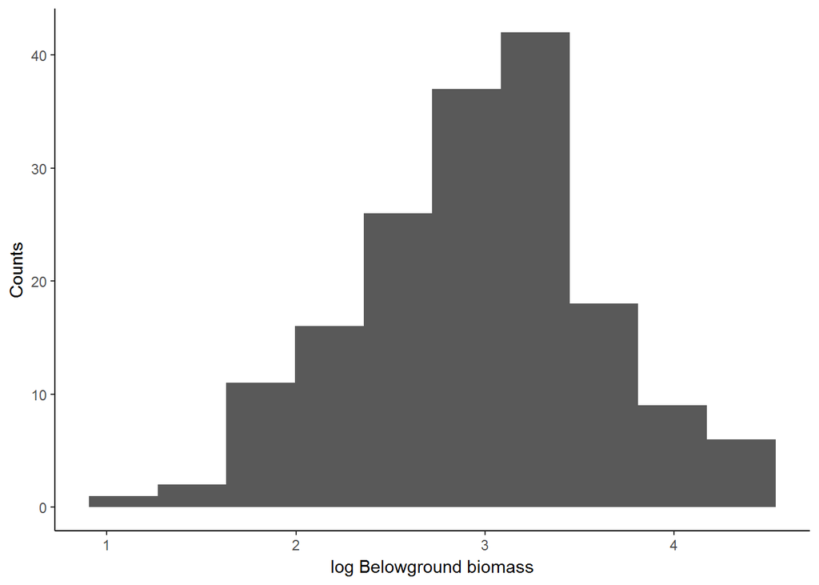

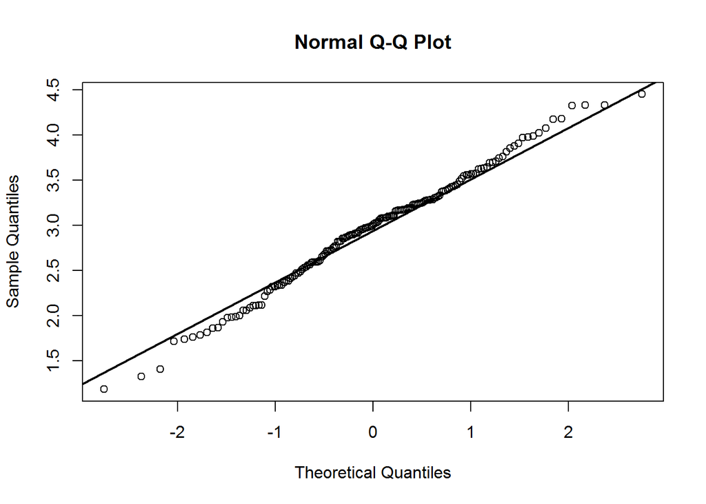

```
##
##  Shapiro-Wilk normality test
##
## data:  log(tran.dat$bg_mass)
## W = 0.99186, p-value = 0.4605
```

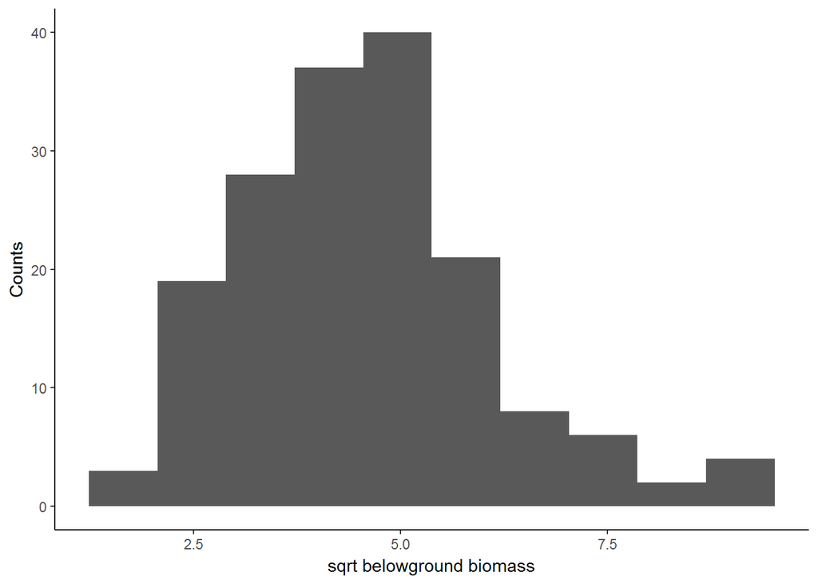

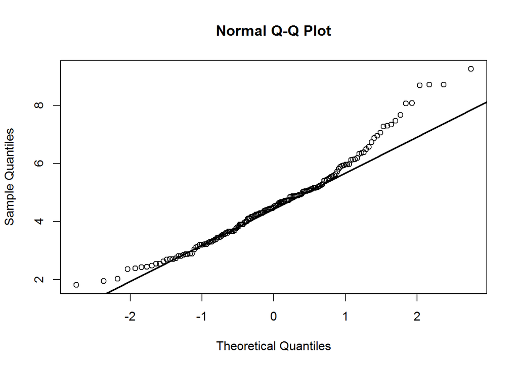

```
##
##  Shapiro-Wilk normality test
##
## data:  sqrt(tran.dat$bg_mass)
## W = 0.96522, p-value = 0.0003244
```

Ratio of above to belowground biomass also appears right skewed. SW test indicates that log transformation is best.

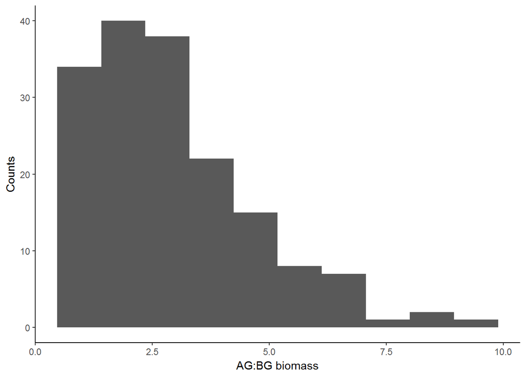

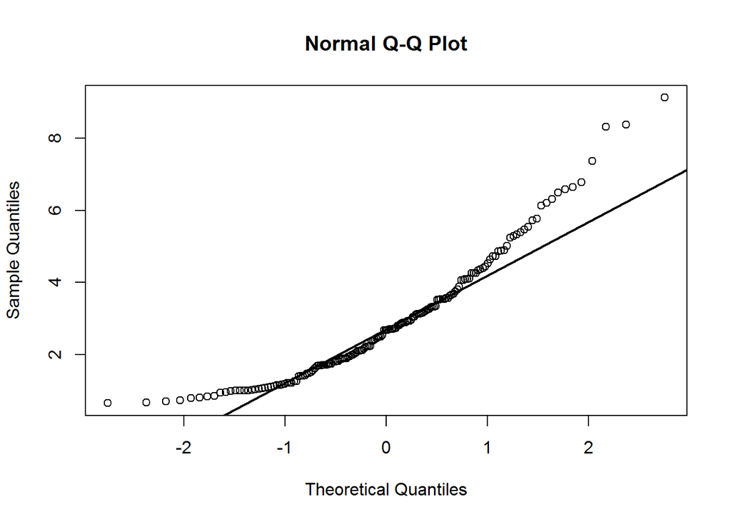

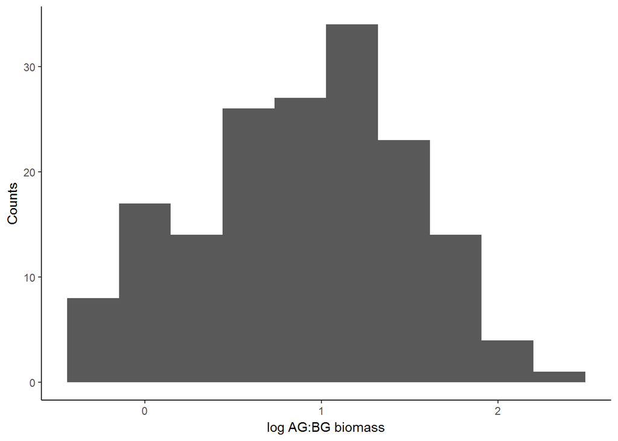

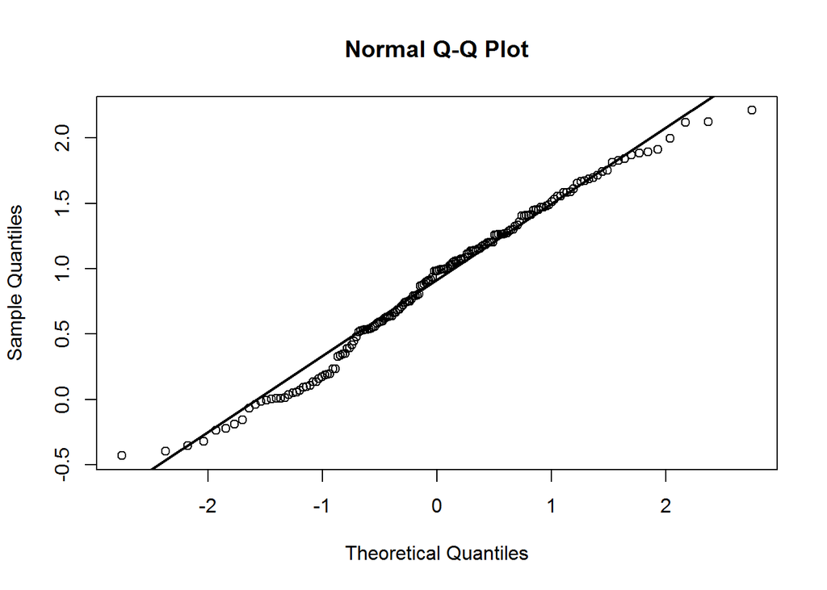

```
##
##  Shapiro-Wilk normality test
##
## data:  log(tran.dat$ag_mass/tran.dat$bg_mass)
## W = 0.98516, p-value = 0.07102
```

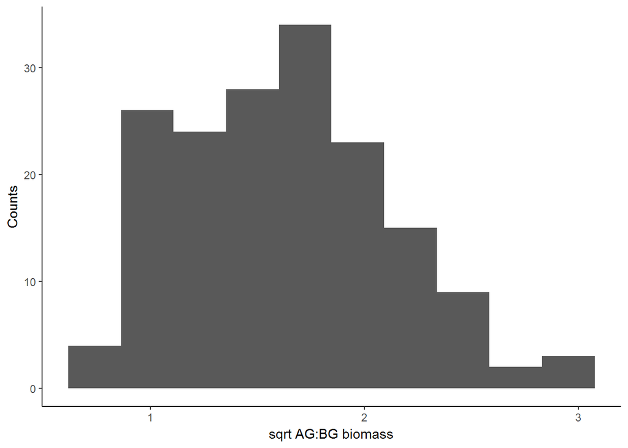

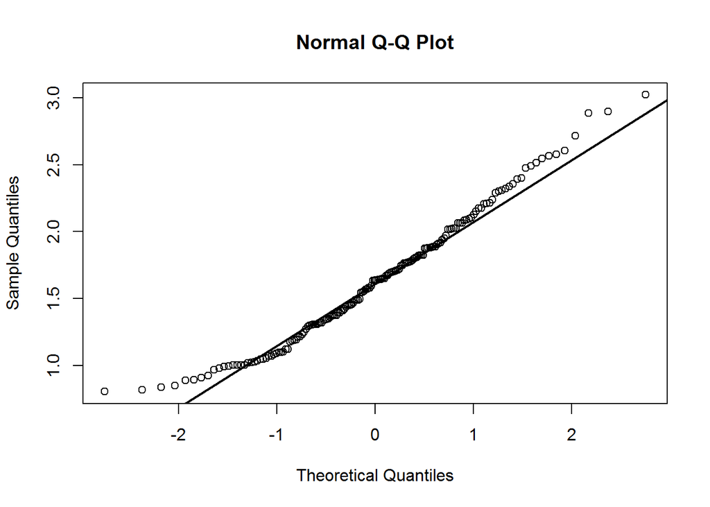

```
##
##  Shapiro-Wilk normality test
##
## data:  sqrt(tran.dat$ag_mass/tran.dat$bg_mass)
## W = 0.97455, p-value = 0.003494
```

Epiphyte load. This one is a bit tricky, any sort of tranformation does not deal with the outliers well.

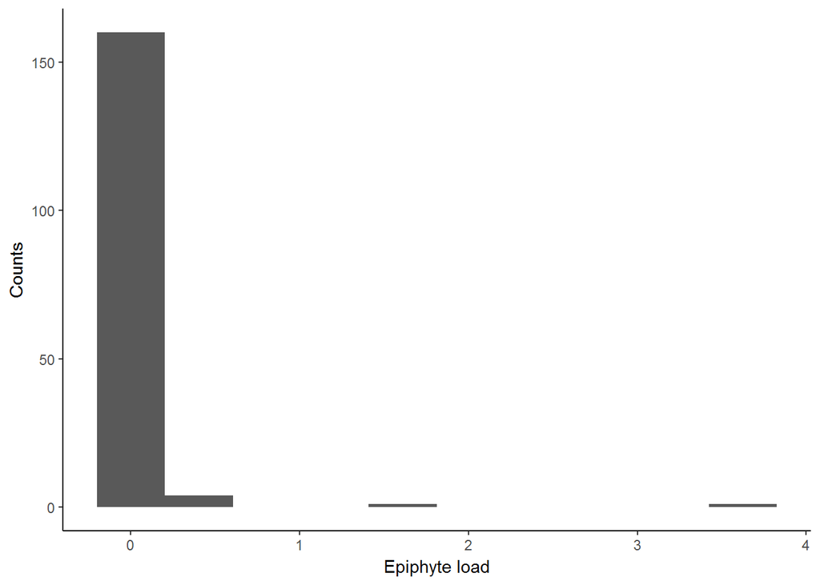

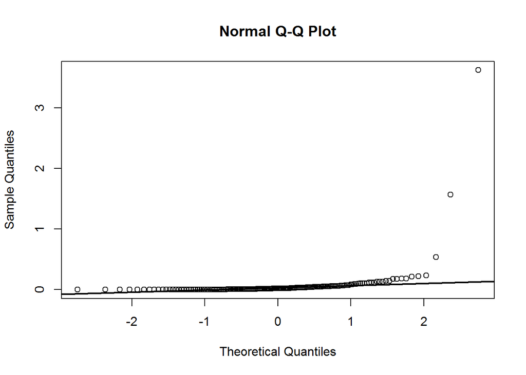

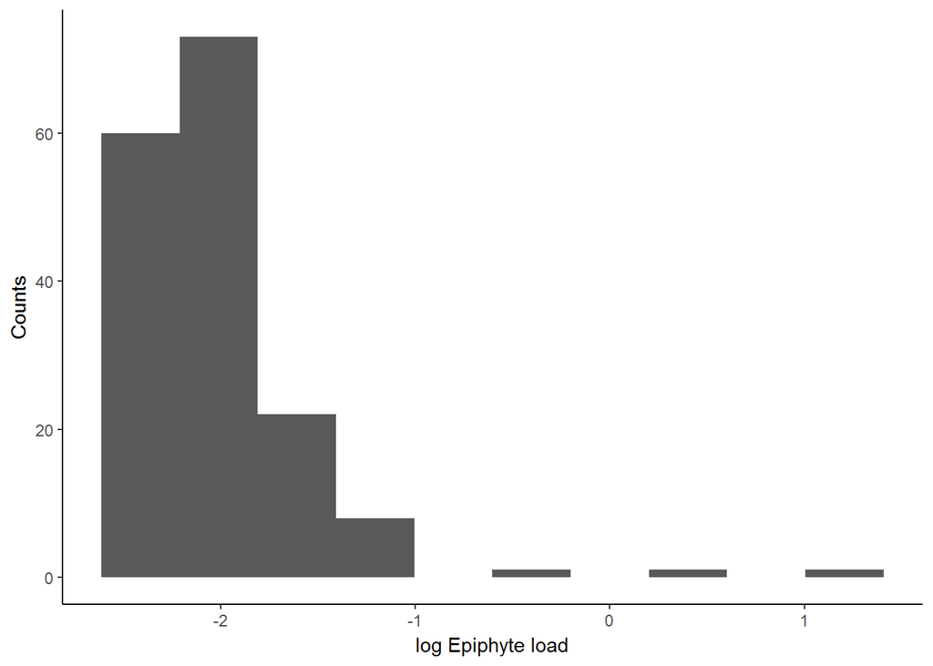

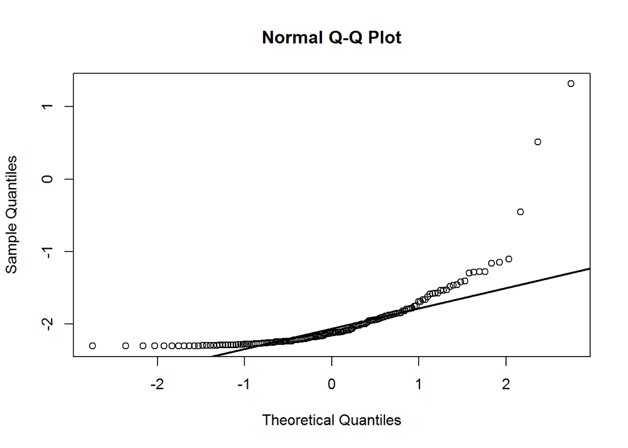

```
##
##  Shapiro-Wilk normality test
##
## data:  log(tran.dat$epimass_shootmass + 0.1)
## W = 0.6323, p-value < 2.2e-16
```

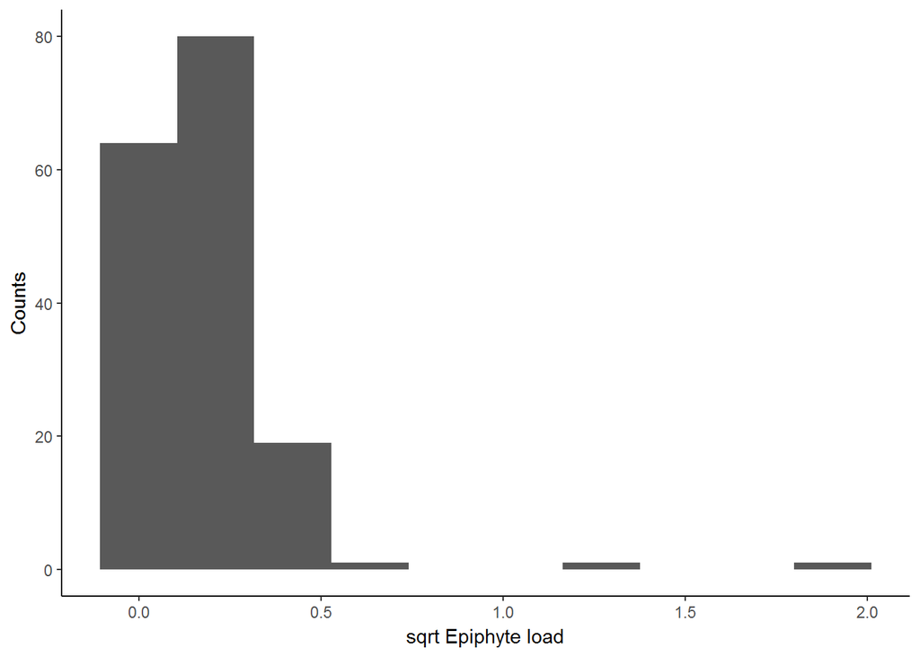

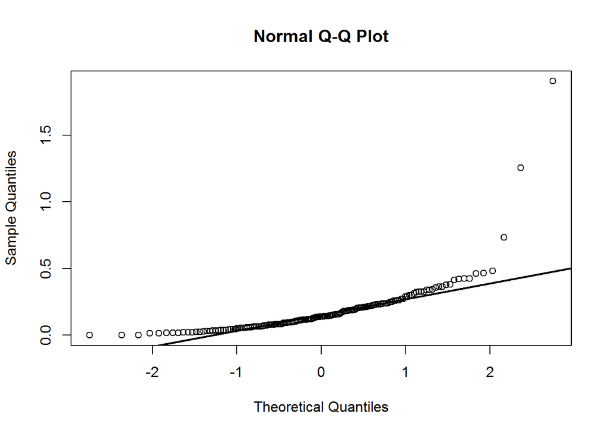

```
##
##  Shapiro-Wilk normality test
##
## data:  sqrt(tran.dat$epimass_shootmass)
## W = 0.59595, p-value < 2.2e-16
```

Grazer load does not respond well to any transformation. Given the distribution of the raw data it may be best to keep it the way it is.

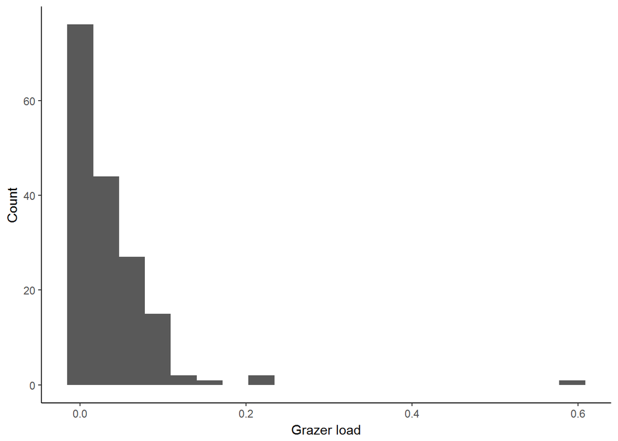

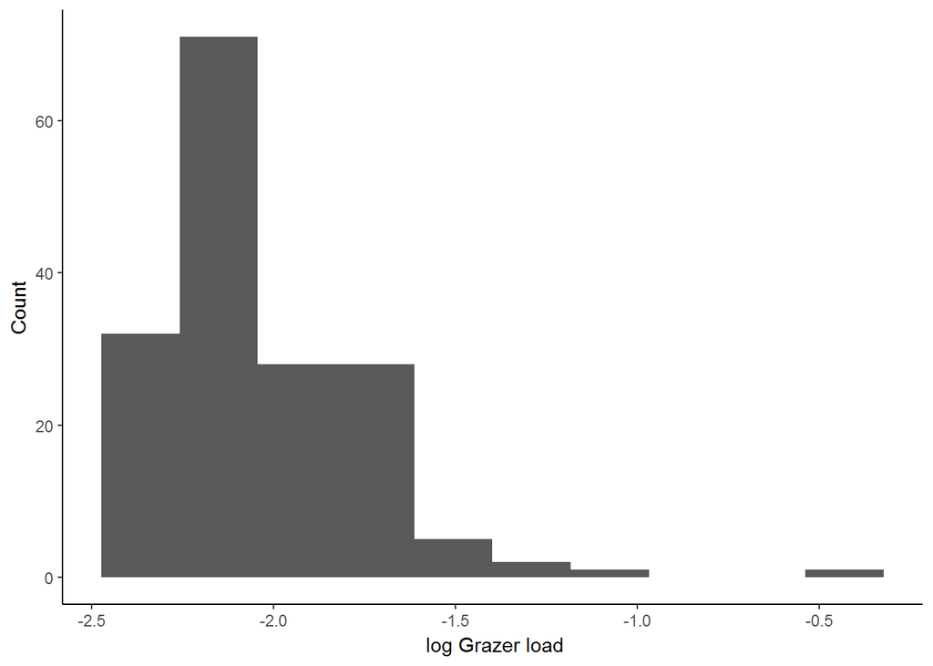

```
##
##  Shapiro-Wilk normality test
##
## data:  log(tran.dat$grazmass_shootmass + 0.1)
## W = 0.81983, p-value = 4.002e-13
```